# Data Analysis: WeRateDogs Twitter Account

Figure 6 shows that the highest rated Dog breed is a Clumber (27) and Figure 7 shows the lowest performing breed to unfortunately be a Japanese Spaniel (5).

*Figure 5 - Rating Average by Dog Type*

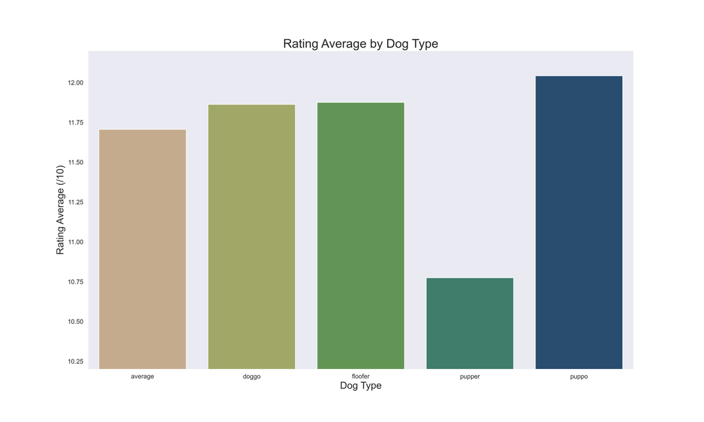

```python
Image(filename='rating_avg_dog_type.png')
```

*Figure 6 - Top 10 Dog Breeds by Rating*

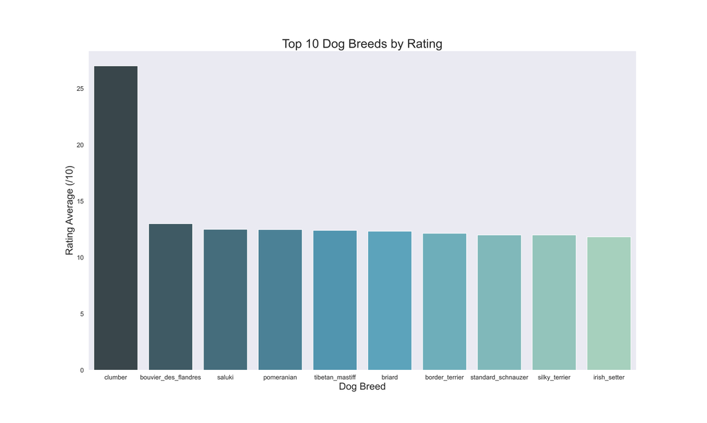

```python
Image(filename='top_rating_avg_dog_breed.png')
```

*Figure 7 - Bottom 10 Dog Breeds by Rating*

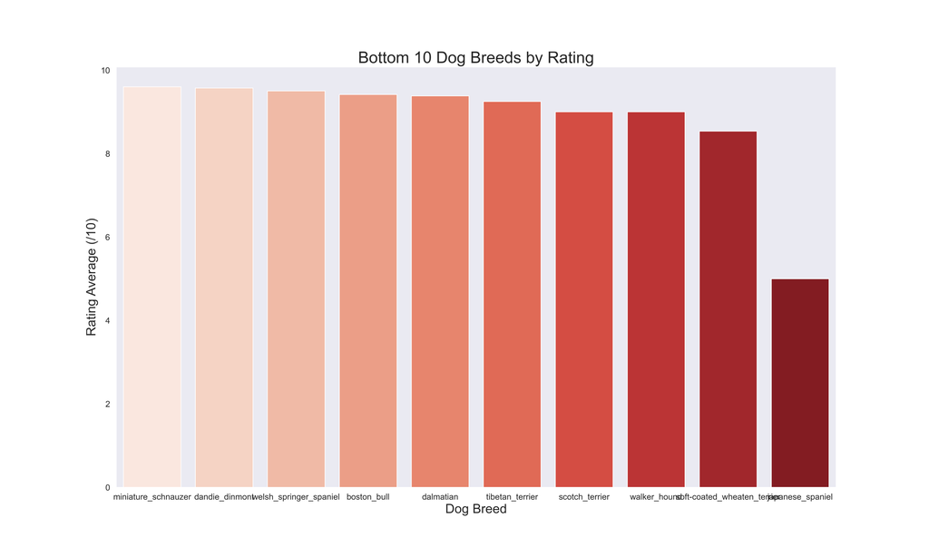

```python
Image(filename='rating_avg_dog_breed.png')
```

### Rating and Audience Interaction

*Figure 8 - Rating Vs Retweet*

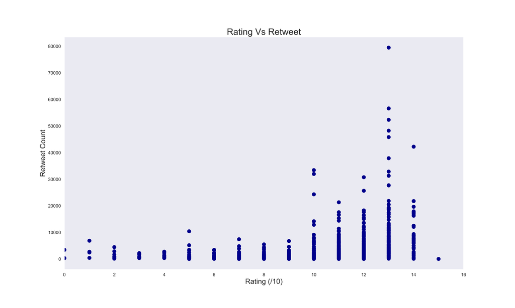

```python
Image(filename='rating_rt.png')
```

*Figure 9 - Rating Vs Favourite*

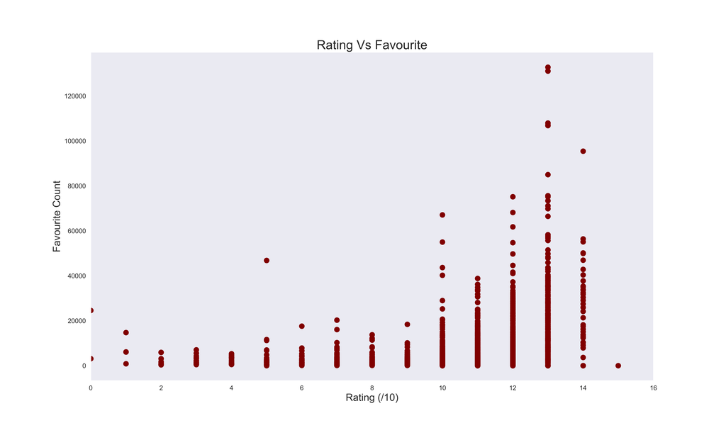

```python
Image(filename='rating_f.png')
```

# Conclusion

In answering the question, *How have ratings trended over time?* I combined a bar chart for monthly tweet count with a line chart of average rating. The visualisation shows a divergence, as tweet count has reduced, rating average has improved.

*What makes a highly rated Dog?* - Of course, there are many attributes that make a Dog unique and highly rateable from gender to size! I decided to focus my attention on Dog type, Dog breed and the name of the Dog to understand how these factors might have impacted the rating.

*In terms of quantity...* Golden Retrievers are quite significantly the most tweeted about Dog breed with a massive 169 tweets, while Pupper's contribute a massive 66.4% of all Dog type tweets. Charlie (or Charlie's) is the most tweeted about Dog with 11 tweets.

*In term of quality...* while Dog type largely appears to be indistinguishable in determining a high rating, Pupper's must be noted for receieving a low average of 10.77 (average rating is 11.71). There are several high performing and low performing Dog breeds which could be mentioned, however the scale is poloarised by a clear Dog breed leader and under-performer. Clumber's have a great rating of 27/10 which is vast in-comparison with Japanese Spaniel's at a 5/10 average.

# Sources

1. https://medium.com/@morganjonesartist/color-guide-to-seaborn-palettes-da849406d44f
2. https://www.cyberdefinitions.com/definitions/DOGGO.html
3. https://twitter.com/dog_rates?ref_src=twsrc%5Egoogle%7Ctwcamp%5Eserp%7Ctwgr%5Eauthor
4. https://matplotlib.org/tutorials/colors/colormaps.html
5. https://matplotlib.org/2.0.2/examples/color/named_colors.html
6. https://docs.conda.io/projects/conda/en/latest/user-guide/cheatsheet.html
7. https://pandas.pydata.org/pandas-docs/stable/user_guide/index.html
8. http://empierce.com/